# Machine Learning Engineer Nanodegree

## Project: Creating Customer Segments

Welcome to the third project of the Machine Learning Engineer Nanodegree! In this notebook, some template code has already been provided for you, and it will be your job to implement the additional functionality necessary to successfully complete this project. Sections that begin with **'Implementation'** in the header indicate that the following block of code will require additional functionality which you must provide. Instructions will be provided for each section and the specifics of the implementation are marked in the code block with a `'TODO'` statement. Please be sure to read the instructions carefully!

In addition to implementing code, there will be questions that you must answer which relate to the project and your implementation. Each section where you will answer a question is preceded by a **'Question X'** header. Carefully read each question and provide thorough answers in the following text boxes that begin with **'Answer:'**. Your project submission will be evaluated based on your answers to each of the questions and the implementation you provide.

> **Note:** Code and Markdown cells can be executed using the **Shift + Enter** keyboard shortcut. In addition, Markdown cells can be edited by typically double-clicking the cell to enter edit mode.

## Getting Started

In this project, you will analyze a dataset containing data on various customers' annual spending amounts (reported in *monetary units*) of diverse product categories for internal structure. One goal of this project is to best describe the variation in the different types of customers that a wholesale distributor interacts with. Doing so would equip the distributor with insight into how to best structure their delivery service to meet the needs of each customer.

The dataset for this project can be found on the [UCI Machine Learning Repository](https://archive.ics.uci.edu/ml/datasets/Wholesale+customers). For the purposes of this project, the features `'Channel'` and `'Region'` will be excluded in the analysis — with focus instead on the six product categories recorded for customers.

Run the code block below to load the wholesale customers dataset, along with a few of the necessary Python libraries required for this project. You will know the dataset loaded successfully if the size of the dataset is reported.

```python
# Import libraries necessary for this project
import numpy as np
import pandas as pd
from IPython.display import display # Allows the use of display() for DataFrames

# Import supplementary visualizations code visuals.py
import visuals as vs

# Pretty display for notebooks
%matplotlib inline

# Load the wholesale customers dataset
try:
    data = pd.read_csv("customers.csv")
    data.drop(['Region', 'Channel'], axis = 1, inplace = True)
    print "Wholesale customers dataset has {} samples with {} features each.".format(*data.shape)
except:
    print "Dataset could not be loaded. Is the dataset missing?"
```

```
Wholesale customers dataset has 440 samples with 6 features each.
```

## Data Exploration

In this section, you will begin exploring the data through visualizations and code to understand how each feature is related to the others. You will observe a statistical description of the dataset, consider the relevance of each feature, and select a few sample data points from the dataset which you will track through the course of this project.

Run the code block below to observe a statistical description of the dataset. Note that the dataset is composed of six important product categories: **'Fresh'**, **'Milk'**, **'Grocery'**, **'Frozen'**, **'Detergents_Paper'**, and **'Delicatessen'**. Consider what each category represents in terms of products you could purchase.

### Implementation: Selecting Samples

To get a better understanding of the customers and how their data will transform through the analysis, it would be best to select a few sample data points and explore them in more detail. In the code block below, add **three** indices of your choice to the `indices` list which will represent the customers to track. It is suggested to try different sets of samples until you obtain customers that vary significantly from one another.

```python
# Display a description of the dataset
display(data.describe())

#import seaborn as sns


#percentiles_data = 100*data.rank(pct=True)
#percentiles_samples[indice1] = percentiles_data.iloc[indices]

#sns.heatmap(percentiles_samples, annot=True)

#print('test1',percentiles_samples)

medd1_Fresh=np.median(data['Fresh'])
medd1_Milk=np.median(data['Milk'])
medd1_Grocery=np.median(data['Grocery'])
medd1_Frozen=np.median(data['Frozen'])
medd1_Detergent=np.median(data['Detergents_Paper'])
medd1_Deli=np.median(data['Delicatessen'])
#print( 'Median Fresh =',medd1_Fresh)
#print( 'Median Milk =',medd1_Milk)
#print( 'Median Grocery =',medd1_Grocery)
#print( 'Median Frozen =',medd1_Frozen)
#print( 'Median Detergents-Paper =',medd1_Detergent)
#print( 'Median Delicatessen =',medd1_Deli)
#print('Of course, the median is defined as the 50% percentile. I must be missing the point of the Viewer request')
q1_Fresh=np.percentile(data['Fresh'],25)
q1_Milk=np.percentile(data['Milk'],25)
q1_Frozen=np.percentile(data['Frozen'],25)
q1_Grocery=np.percentile(data['Grocery'],25)
q1_Deterg=np.percentile(data['Detergents_Paper'],25)
q1_Deli=np.percentile(data['Delicatessen'],25)

q3_Fresh=np.percentile(data['Fresh'],75)
q3_Milk=np.percentile(data['Milk'],75)
q3_Frozen=np.percentile(data['Frozen'],75)
q3_Grocery=np.percentile(data['Grocery'],75)
q3_Deterg=np.percentile(data['Detergents_Paper'],75)
q3_Deli=np.percentile(data['Delicatessen'],75)
#print q3_Fresh, q3_Milk

display('1ST Quartile Fresh', data.loc[data.Fresh < q1_Fresh, :].head())
display('1ST Quartile Milk', data.loc[data.Milk < q1_Milk, :].head())
display('1ST Quartile Frozen', data.loc[data.Frozen < q1_Frozen, :].head())
display('1ST Quartile Grocery', data.loc[data.Grocery < q1_Grocery, :].head())
display('1ST Quartile Detergents_Paper', data.loc[data.Detergents_Paper < q1_Deterg, :].head())
display('1ST Quartile Deli', data.loc[data.Delicatessen < q1_Deli, :].head())

display('Median Fresh', data.loc[data.Fresh < medd1_Fresh, :].head())
display('Median  Milk', data.loc[data.Milk < medd1_Milk, :].head())
display('Median  Frozen', data.loc[data.Frozen < medd1_Frozen, :].head())
display('Median  Grocery', data.loc[data.Grocery < medd1_Grocery, :].head())
display('Median  Detergents_Paper', data.loc[data.Detergents_Paper < medd1_Detergent, :].head())
display('Median Deli', data.loc[data.Delicatessen < medd1_Deli, :].head())


display('3rd Quartile Fresh', data.loc[data.Fresh < q3_Fresh, :].head())
display('3rd Quartile Milk', data.loc[data.Milk < q3_Milk, :].head())
display('3rd Quartile Frozen', data.loc[data.Frozen < q3_Frozen, :].head())
display('3rd Quartile Grocery', data.loc[data.Grocery < q3_Grocery, :].head())
display('3rd Quartile Detergents_Paper', data.loc[data.Detergents_Paper < q3_Deterg, :].head())
display('3rd Quartile Deli', data.loc[data.Delicatessen < q3_Deli, :].head())
```

|  | Fresh | Milk | Grocery | Frozen | Detergents_Paper | Delicatessen |
| --- | --- | --- | --- | --- | --- | --- |
| count | 440.000000 | 440.000000 | 440.000000 | 440.000000 | 440.000000 | 440.000000 |
| mean | 12000.297727 | 5796.265909 | 7951.277273 | 3071.931818 | 2881.493182 | 1524.870455 |
| std | 12647.328865 | 7380.377175 | 9503.162829 | 4854.673333 | 4767.854448 | 2820.105937 |
| min | 3.000000 | 55.000000 | 3.000000 | 25.000000 | 3.000000 | 3.000000 |
| 25% | 3127.750000 | 1533.000000 | 2153.000000 | 742.250000 | 256.750000 | 408.250000 |
| 50% | 8504.000000 | 3627.000000 | 4755.500000 | 1526.000000 | 816.500000 | 965.500000 |
| 75% | 16933.750000 | 7190.250000 | 10655.750000 | 3554.250000 | 3922.000000 | 1820.250000 |
| max | 112151.000000 | 73498.000000 | 92780.000000 | 60869.000000 | 40827.000000 | 47943.000000 |

```
'1ST Quartile Fresh'
```

|  | Fresh | Milk | Grocery | Frozen | Detergents_Paper | Delicatessen |
| --- | --- | --- | --- | --- | --- | --- |
| 16 | 1020 | 8816 | 12121 | 134 | 4508 | 1080 |
| 31 | 2612 | 4339 | 3133 | 2088 | 820 | 985 |
| 34 | 1502 | 1979 | 2262 | 425 | 483 | 395 |
| 35 | 688 | 5491 | 11091 | 833 | 4239 | 436 |
| 43 | 630 | 11095 | 23998 | 787 | 9529 | 72 |

```
'1ST Quartile Milk'
```

|  | Fresh | Milk | Grocery | Frozen | Detergents_Paper | Delicatessen |
| --- | --- | --- | --- | --- | --- | --- |
| 3 | 13265 | 1196 | 4221 | 6404 | 507 | 1788 |
| 11 | 13146 | 1124 | 4523 | 1420 | 549 | 497 |
| 15 | 10253 | 1114 | 3821 | 397 | 964 | 412 |
| 21 | 5567 | 871 | 2010 | 3383 | 375 | 569 |
| 26 | 9898 | 961 | 2861 | 3151 | 242 | 833 |

```
'1ST Quartile Frozen'
```

|  | Fresh | Milk | Grocery | Frozen | Detergents_Paper | Delicatessen |
| --- | --- | --- | --- | --- | --- | --- |
| 0 | 12669 | 9656 | 7561 | 214 | 2674 | 1338 |
| 5 | 9413 | 8259 | 5126 | 666 | 1795 | 1451 |
| 6 | 12126 | 3199 | 6975 | 480 | 3140 | 545 |
| 8 | 5963 | 3648 | 6192 | 425 | 1716 | 750 |
| 12 | 31714 | 12319 | 11757 | 287 | 3881 | 2931 |

```
'1ST Quartile Grocery'
```

|  | Fresh | Milk | Grocery | Frozen | Detergents_Paper | Delicatessen |
| --- | --- | --- | --- | --- | --- | --- |
| 21 | 5567 | 871 | 2010 | 3383 | 375 | 569 |
| 39 | 56159 | 555 | 902 | 10002 | 212 | 2916 |
| 50 | 6269 | 1095 | 1980 | 3860 | 609 | 2162 |
| 54 | 27329 | 1449 | 1947 | 2436 | 204 | 1333 |
| 58 | 13779 | 1970 | 1648 | 596 | 227 | 436 |

```
'1ST Quartile Detergents_Paper'
```

|  | Fresh | Milk | Grocery | Frozen | Detergents_Paper | Delicatessen |
| --- | --- | --- | --- | --- | --- | --- |
| 26 | 9898 | 961 | 2861 | 3151 | 242 | 833 |
| 27 | 14276 | 803 | 3045 | 485 | 100 | 518 |
| 39 | 56159 | 555 | 902 | 10002 | 212 | 2916 |
| 54 | 27329 | 1449 | 1947 | 2436 | 204 | 1333 |
| 58 | 13779 | 1970 | 1648 | 596 | 227 | 436 |

```
'1ST Quartile Deli'
```

|  | Fresh | Milk | Grocery | Frozen | Detergents_Paper | Delicatessen |
| --- | --- | --- | --- | --- | --- | --- |
| 25 | 16165 | 4230 | 7595 | 201 | 4003 | 57 |
| 32 | 21632 | 1318 | 2886 | 266 | 918 | 405 |
| 34 | 1502 | 1979 | 2262 | 425 | 483 | 395 |
| 42 | 10850 | 7555 | 14961 | 188 | 6899 | 46 |
| 43 | 630 | 11095 | 23998 | 787 | 9529 | 72 |

```
'Median Fresh'
```

|  | Fresh | Milk | Grocery | Frozen | Detergents_Paper | Delicatessen |
| --- | --- | --- | --- | --- | --- | --- |
| 1 | 7057 | 9810 | 9568 | 1762 | 3293 | 1776 |
| 2 | 6353 | 8808 | 7684 | 2405 | 3516 | 7844 |
| 7 | 7579 | 4956 | 9426 | 1669 | 3321 | 2566 |
| 8 | 5963 | 3648 | 6192 | 425 | 1716 | 750 |
| 9 | 6006 | 11093 | 18881 | 1159 | 7425 | 2098 |

```
'Median  Milk'
```

|  | Fresh | Milk | Grocery | Frozen | Detergents_Paper | Delicatessen |
| --- | --- | --- | --- | --- | --- | --- |
| 3 | 13265 | 1196 | 4221 | 6404 | 507 | 1788 |
| 6 | 12126 | 3199 | 6975 | 480 | 3140 | 545 |
| 11 | 13146 | 1124 | 4523 | 1420 | 549 | 497 |
| 15 | 10253 | 1114 | 3821 | 397 | 964 | 412 |
| 19 | 7780 | 2495 | 9464 | 669 | 2518 | 501 |

```
'Median  Frozen'
```

|  | Fresh | Milk | Grocery | Frozen | Detergents_Paper | Delicatessen |
| --- | --- | --- | --- | --- | --- | --- |
| 0 | 12669 | 9656 | 7561 | 214 | 2674 | 1338 |
| 5 | 9413 | 8259 | 5126 | 666 | 1795 | 1451 |
| 6 | 12126 | 3199 | 6975 | 480 | 3140 | 545 |
| 8 | 5963 | 3648 | 6192 | 425 | 1716 | 750 |
| 9 | 6006 | 11093 | 18881 | 1159 | 7425 | 2098 |

```
'Median  Grocery'
```

|  | Fresh | Milk | Grocery | Frozen | Detergents_Paper | Delicatessen |
| --- | --- | --- | --- | --- | --- | --- |
| 3 | 13265 | 1196 | 4221 | 6404 | 507 | 1788 |
| 11 | 13146 | 1124 | 4523 | 1420 | 549 | 497 |
| 15 | 10253 | 1114 | 3821 | 397 | 964 | 412 |
| 17 | 5876 | 6157 | 2933 | 839 | 370 | 4478 |
| 20 | 17546 | 4519 | 4602 | 1066 | 2259 | 2124 |

```
'Median  Detergents_Paper'
```

|  | Fresh | Milk | Grocery | Frozen | Detergents_Paper | Delicatessen |
| --- | --- | --- | --- | --- | --- | --- |
| 3 | 13265 | 1196 | 4221 | 6404 | 507 | 1788 |
| 11 | 13146 | 1124 | 4523 | 1420 | 549 | 497 |
| 17 | 5876 | 6157 | 2933 | 839 | 370 | 4478 |
| 21 | 5567 | 871 | 2010 | 3383 | 375 | 569 |
| 26 | 9898 | 961 | 2861 | 3151 | 242 | 833 |

```
'Median Deli'
```

|  | Fresh | Milk | Grocery | Frozen | Detergents_Paper | Delicatessen |
| --- | --- | --- | --- | --- | --- | --- |
| 6 | 12126 | 3199 | 6975 | 480 | 3140 | 545 |
| 8 | 5963 | 3648 | 6192 | 425 | 1716 | 750 |
| 11 | 13146 | 1124 | 4523 | 1420 | 549 | 497 |
| 13 | 21217 | 6208 | 14982 | 3095 | 6707 | 602 |
| 15 | 10253 | 1114 | 3821 | 397 | 964 | 412 |

```
'3rd Quartile Fresh'
```

|  | Fresh | Milk | Grocery | Frozen | Detergents_Paper | Delicatessen |
| --- | --- | --- | --- | --- | --- | --- |
| 0 | 12669 | 9656 | 7561 | 214 | 2674 | 1338 |
| 1 | 7057 | 9810 | 9568 | 1762 | 3293 | 1776 |
| 2 | 6353 | 8808 | 7684 | 2405 | 3516 | 7844 |
| 3 | 13265 | 1196 | 4221 | 6404 | 507 | 1788 |
| 5 | 9413 | 8259 | 5126 | 666 | 1795 | 1451 |

```
'3rd Quartile Milk'
```

|  | Fresh | Milk | Grocery | Frozen | Detergents_Paper | Delicatessen |
| --- | --- | --- | --- | --- | --- | --- |
| 3 | 13265 | 1196 | 4221 | 6404 | 507 | 1788 |
| 4 | 22615 | 5410 | 7198 | 3915 | 1777 | 5185 |
| 6 | 12126 | 3199 | 6975 | 480 | 3140 | 545 |
| 7 | 7579 | 4956 | 9426 | 1669 | 3321 | 2566 |
| 8 | 5963 | 3648 | 6192 | 425 | 1716 | 750 |

```
'3rd Quartile Frozen'
```

|  | Fresh | Milk | Grocery | Frozen | Detergents_Paper | Delicatessen |
| --- | --- | --- | --- | --- | --- | --- |
| 0 | 12669 | 9656 | 7561 | 214 | 2674 | 1338 |
| 1 | 7057 | 9810 | 9568 | 1762 | 3293 | 1776 |
| 2 | 6353 | 8808 | 7684 | 2405 | 3516 | 7844 |
| 5 | 9413 | 8259 | 5126 | 666 | 1795 | 1451 |
| 6 | 12126 | 3199 | 6975 | 480 | 3140 | 545 |

```
'3rd Quartile Grocery'
```

|  | Fresh | Milk | Grocery | Frozen | Detergents_Paper | Delicatessen |
| --- | --- | --- | --- | --- | --- | --- |
| 0 | 12669 | 9656 | 7561 | 214 | 2674 | 1338 |
| 1 | 7057 | 9810 | 9568 | 1762 | 3293 | 1776 |
| 2 | 6353 | 8808 | 7684 | 2405 | 3516 | 7844 |
| 3 | 13265 | 1196 | 4221 | 6404 | 507 | 1788 |
| 4 | 22615 | 5410 | 7198 | 3915 | 1777 | 5185 |

```
'3rd Quartile Detergents_Paper'
```

|  | Fresh | Milk | Grocery | Frozen | Detergents_Paper | Delicatessen |
| --- | --- | --- | --- | --- | --- | --- |
| 0 | 12669 | 9656 | 7561 | 214 | 2674 | 1338 |
| 1 | 7057 | 9810 | 9568 | 1762 | 3293 | 1776 |
| 2 | 6353 | 8808 | 7684 | 2405 | 3516 | 7844 |
| 3 | 13265 | 1196 | 4221 | 6404 | 507 | 1788 |
| 4 | 22615 | 5410 | 7198 | 3915 | 1777 | 5185 |

```
'3rd Quartile Deli'
```

|  | Fresh | Milk | Grocery | Frozen | Detergents_Paper | Delicatessen |
| --- | --- | --- | --- | --- | --- | --- |
| 0 | 12669 | 9656 | 7561 | 214 | 2674 | 1338 |
| 1 | 7057 | 9810 | 9568 | 1762 | 3293 | 1776 |
| 3 | 13265 | 1196 | 4221 | 6404 | 507 | 1788 |
| 5 | 9413 | 8259 | 5126 | 666 | 1795 | 1451 |
| 6 | 12126 | 3199 | 6975 | 480 | 3140 | 545 |

```python
# TODO: Select three indices of your choice you wish to sample from the dataset
indices = [1,3,89,47,120,201,439,432,333]

# Create a DataFrame of the chosen samples
samples = pd.DataFrame(data.loc[indices], columns = data.keys()).reset_index(drop = True)
print "Chosen samples of wholesale customers dataset:"
display(samples)
#print data

#data.columns
```

```
Chosen samples of wholesale customers dataset:
```

|  | Fresh | Milk | Grocery | Frozen | Detergents_Paper | Delicatessen |
| --- | --- | --- | --- | --- | --- | --- |
| 0 | 7057 | 9810 | 9568 | 1762 | 3293 | 1776 |
| 1 | 13265 | 1196 | 4221 | 6404 | 507 | 1788 |
| 2 | 24904 | 3836 | 5330 | 3443 | 454 | 3178 |
| 3 | 44466 | 54259 | 55571 | 7782 | 24171 | 6465 |
| 4 | 17160 | 1200 | 3412 | 2417 | 174 | 1136 |
| 5 | 4484 | 14399 | 24708 | 3549 | 14235 | 1681 |
| 6 | 2787 | 1698 | 2510 | 65 | 477 | 52 |
| 7 | 21117 | 1162 | 4754 | 269 | 1328 | 395 |
| 8 | 8565 | 4980 | 67298 | 131 | 38102 | 1215 |

### Question 1

Consider the total purchase cost of each product category and the statistical description of the dataset above for your sample customers.

- What kind of establishment (customer) could each of the three samples you've chosen represent?

Knowing this, how do your samples compare? Does that help in driving your insight into what kind of establishments they might be?

Clarification Requested: In your lexicon: is a "sample" defined as one of the 440 customer data points? or is a "sample" a random subset of x (>1) these 440 customer data points?

A: The establishments that would buy more milk & detergents paper then groceries would be a fast food corner store. The 'fresh' would require more in-store labor so more overhead these stores would not have! Also, small stores would need a shopper volume to 'move' the fresh food because these foods spoil quickly, so again small stores would likely not carry these items.

But a larger store - super market - would sell more 'fresh', 'frozen', and 'delicatessen' items because they had the shopper traffic to 'turn the inventory over' these items before they would spoil and would have the volume to support the addition labor overhead.

If some customers were restaurants or hotels, they would order greater fresh and frozen volumes to satisfy the restaurant's customers. These same restaurants-hotels would NOT sell detergents-paper at all, so the detergents-paper ordered would consumed by restaurant internally. This means that the restaurant would not order large volumes of detergent-paper.

Using this logic: Samples 0, 3, 5, 8: aresstores Samples 1, 2, 4, 6 : are restaurants Sample 7: likely a large restaurant

### Implementation: Feature Relevance

One interesting thought to consider is if one (or more) of the six product categories is actually relevant for understanding customer purchasing. That is to say, is it possible to determine whether customers purchasing some amount of one category of products will necessarily purchase some proportional amount of another category of products? We can make this determination quite easily by training a supervised regression learner on a subset of the data with one feature removed, and then score how well that model can predict the removed feature.

In the code block below, you will need to implement the following:

- Assign `new_data` a copy of the data by removing a feature of your choice using the `DataFrame.drop` function.
- Use `sklearn.cross_validation.train_test_split` to split the dataset into training and testing sets.
  - Use the removed feature as your target label. Set a `test_size` of `0.25` and set a `random_state`.
- Import a decision tree regressor, set a `random_state`, and fit the learner to the training data.
- Report the prediction score of the testing set using the regressor's `score` function.

```python
# TODO: Make a copy of the DataFrame, using the 'drop' function to drop the given feature
#new_data = data.drop('milk',axis = 1)

from sklearn.model_selection import cross_val_score
from sklearn.tree import DecisionTreeRegressor
from sklearn.model_selection import train_test_split


variables1 = list(data.columns)
#print new_data
#new_data = data.drop('Milk', axis = 1)
#y = data['Milk']

#print y




# TODO: Split the data into training and testing sets(0.25) using the given feature as the target
# Set a random state.
for dep_var1 in variables1:

    new_data    = data.drop([dep_var1], axis = 1)

    features_1  = pd.DataFrame(data.loc[: dep_var1])



    X_train, X_test, y_train, y_test = train_test_split(new_data,
                                                    features_1,
                                                    test_size = 0.25,
                                                    random_state = 5)

    # TODO: Create a decision tree regressor and fit it to the training set
    regressor = DecisionTreeRegressor(random_state=5)

    # TODO: Report the score of the prediction using the testing set

    regressor.fit(X_train, y_train)
    #get_params(deep=True)[regressor.fit]

    #predictions_test  = regressor.predict(X_test)
    predictions_train = regressor.predict(X_train)

    score1 = regressor.score(X_test,    y_test)
    score2 = regressor.score(X_train,    y_train)
    print('Test  Data Score for  {} as dependent variable: {}'.format(dep_var1, score1)  )

    print('Train Data Score for  {} as dependent variable: {}\n'.format(dep_var1, score2)  )
```

```
Test  Data Score for  Fresh as dependent variable: 0.134633933502
Train Data Score for  Fresh as dependent variable: 1.0

Test  Data Score for  Milk as dependent variable: 0.850388664336
Train Data Score for  Milk as dependent variable: 1.0

Test  Data Score for  Grocery as dependent variable: 0.773167031765
Train Data Score for  Grocery as dependent variable: 1.0

Test  Data Score for  Frozen as dependent variable: 0.746654886374
Train Data Score for  Frozen as dependent variable: 1.0

Test  Data Score for  Detergents_Paper as dependent variable: 0.714641785806
Train Data Score for  Detergents_Paper as dependent variable: 1.0

Test  Data Score for  Delicatessen as dependent variable: 0.718292268271
Train Data Score for  Delicatessen as dependent variable: 1.0
```

### Question 2

- Which feature did you attempt to predict?
- What was the reported prediction score?
- Is this feature necessary for identifying customers' spending habits?

**Hint:** The coefficient of determination, `R^2`, is scored between 0 and 1, with 1 being a perfect fit. A negative `R^2` implies the model fails to fit the data. If you get a low score for a particular feature, that lends us to beleive that that feature point is hard to predict using the other features, thereby making it an important feature to consider when considering relevance.

A: I attempted all the variables as the dependent variable. B: The test predictions R-sq scores were: Fresh .135, Milk .850, Geocery .773, Frozen .747, Detergent-Paper .715, Delicatessen .718 Note: If I change the random_state, the test R-sq scores change (- sometimes greatly Fresh from .13 to .35)  
C. Fresh with the lowest R-sq value albeit greater than 0.0; (as I understand relevence), this 'Fresh' will be the hardest variable to predict and therefore the most relevent.

### Visualize Feature Distributions

To get a better understanding of the dataset, we can construct a scatter matrix of each of the six product features present in the data. If you found that the feature you attempted to predict above is relevant for identifying a specific customer, then the scatter matrix below may not show any correlation between that feature and the others. Conversely, if you believe that feature is not relevant for identifying a specific customer, the scatter matrix might show a correlation between that feature and another feature in the data. Run the code block below to produce a scatter matrix.

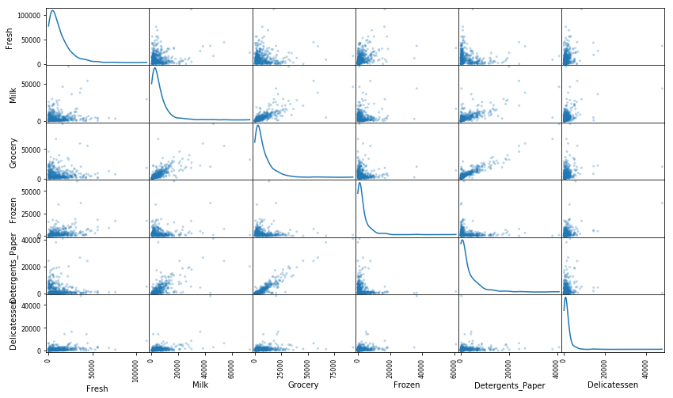

```python
# Produce a scatter matrix for each pair of features in the data
pd.scatter_matrix(data, alpha = 0.3, figsize = (14,8), diagonal = 'kde');




#This is great!!
```

### Question 3

- Using the scatter matrix as a reference, discuss the distribution of the dataset, specifically talk about the normality, outliers, large number of data points near 0 among others. If you need to sepearate out some of the plots individually to further accentuate your point, you may do so as well.
- Are there any pairs of features which exhibit some degree of correlation?
- Does this confirm or deny your suspicions about the relevance of the feature you attempted to predict?
- How is the data for those features distributed?

**Hint:** Is the data normally distributed? Where do most of the data points lie? You can use [corr()](https://pandas.pydata.org/pandas-docs/stable/generated/pandas.DataFrame.corr.html) to get the feature correlations and then visualize them using a [heatmap](http://seaborn.pydata.org/generated/seaborn.heatmap.html)(the data that would be fed into the heatmap would be the correlation values, for eg: `data.corr()`) to gain further insight.